# Project: Investigate a Dataset - [TMDB Movies]

- Introduction
- Data Wrangling
- Exploratory Data Analysis
- Conclusions

## Introduction

### Dataset Description

In this project I will use a TMBD dataset, The Movie Database (TMDb), that contains information about more than 10 000 movies all over the years since 1960 and until 2015.

The original dataset has 21 columns: id - unique identification of each movie, imdb_id, popularity, budget, revenue, original_title, cast, homepage, director, tagline, keywords, overview, runtime, genres, production_companies, release_date, vote_count, vote_average, release_year, budget_adj and revenue_adj - budget and revenue in terms of 2010 dollars, accounting for inflation over time.

During the project I will analyse the columns and do several changes in order to clean data and make it useful for the analysis. I will also create new dataframes and relate them with the origininal. All steps of the cleaning and analysis of the data will be explained along the project.

### Question(s) for Analysis

1. Which variables affect the popularity of a movie?
2. Movies release per year?
3. What is the impact of genres in the movies statistics?
4. Top 5 in movies?
5. Budget vs Revenue?

First, I will import the libraries used in this project:

```python
import pandas as pd
import numpy as np
import matplotlib.pyplot as plt
```

## Data Wrangling

### General Properties

Read the csv file into a pandas dataframe and name it "movies":

```python
movies=pd.read_csv("Database_TMDb_movie_data/tmdb-movies.csv")
movies.head(2)
```

|  | id | imdb_id | popularity | budget | revenue | original_title | cast | homepage | director | tagline | ... | overview | runtime | genres | production_companies | release_date | vote_count | vote_average | release_year | budget_adj | revenue_adj |
| --- | --- | --- | --- | --- | --- | --- | --- | --- | --- | --- | --- | --- | --- | --- | --- | --- | --- | --- | --- | --- | --- |
| 0 | 135397 | tt0369610 | 32.985763 | 150000000 | 1513528810 | Jurassic World | Chris Pratt\|Bryce Dallas Howard\|Irrfan Khan\|Vi... | http://www.jurassicworld.com/ | Colin Trevorrow | The park is open. | ... | Twenty-two years after the events of Jurassic ... | 124 | Action\|Adventure\|Science Fiction\|Thriller | Universal Studios\|Amblin Entertainment\|Legenda... | 6/9/15 | 5562 | 6.5 | 2015 | 1.379999e+08 | 1.392446e+09 |
| 1 | 76341 | tt1392190 | 28.419936 | 150000000 | 378436354 | Mad Max: Fury Road | Tom Hardy\|Charlize Theron\|Hugh Keays-Byrne\|Nic... | http://www.madmaxmovie.com/ | George Miller | What a Lovely Day. | ... | An apocalyptic story set in the furthest reach... | 120 | Action\|Adventure\|Science Fiction\|Thriller | Village Roadshow Pictures\|Kennedy Miller Produ... | 5/13/15 | 6185 | 7.1 | 2015 | 1.379999e+08 | 3.481613e+08 |

2 rows × 21 columns

Check the shape of the dataframe (10866 lines and 21 columsn):

```python
movies.shape
```

```
(10866, 21)
```

Check general info: names of the columns, dtypes, non-null:

```python
movies.info()
```

```
<class 'pandas.core.frame.DataFrame'>
RangeIndex: 10866 entries, 0 to 10865
Data columns (total 21 columns):
 #   Column                Non-Null Count  Dtype
---  ------                --------------  -----
 0   id                    10866 non-null  int64
 1   imdb_id               10856 non-null  object
 2   popularity            10866 non-null  float64
 3   budget                10866 non-null  int64
 4   revenue               10866 non-null  int64
 5   original_title        10866 non-null  object
 6   cast                  10790 non-null  object
 7   homepage              2936 non-null   object
 8   director              10822 non-null  object
 9   tagline               8042 non-null   object
 10  keywords              9373 non-null   object
 11  overview              10862 non-null  object
 12  runtime               10866 non-null  int64
 13  genres                10843 non-null  object
 14  production_companies  9836 non-null   object
 15  release_date          10866 non-null  object
 16  vote_count            10866 non-null  int64
 17  vote_average          10866 non-null  float64
 18  release_year          10866 non-null  int64
 19  budget_adj            10866 non-null  float64
 20  revenue_adj           10866 non-null  float64
dtypes: float64(4), int64(6), object(11)
memory usage: 1.7+ MB
```

First, I can see that there are some null values and a column with a wrong dtype ("release_date"). Later I will work on these issues. Below I can check for the null values in each columns :

```python
movies.isnull().sum()
```

```
id                         0
imdb_id                   10
popularity                 0
budget                     0
revenue                    0
original_title             0
cast                      76
homepage                7930
director                  44
tagline                 2824
keywords                1493
overview                   4
runtime                    0
genres                    23
production_companies    1030
release_date               0
vote_count                 0
vote_average               0
release_year               0
budget_adj                 0
revenue_adj                0
dtype: int64
```

Check the duplicates:

```python
movies.duplicated().sum()
```

```
1
```

```python
movies.nunique()
```

```
id                      10865
imdb_id                 10855
popularity              10814
budget                    557
revenue                  4702
original_title          10571
cast                    10719
homepage                 2896
director                 5067
tagline                  7997
keywords                 8804
overview                10847
runtime                   247
genres                   2039
production_companies     7445
release_date             5909
vote_count               1289
vote_average               72
release_year               56
budget_adj               2614
revenue_adj              4840
dtype: int64
```

As seen above, there is one line duplicated, and with the same "id" (10865 id's instead of 10866), that must be dropped.

Check the statistics:

```python
movies.describe()
```

|  | id | popularity | budget | revenue | runtime | vote_count | vote_average | release_year | budget_adj | revenue_adj |
| --- | --- | --- | --- | --- | --- | --- | --- | --- | --- | --- |
| count | 10866.000000 | 10866.000000 | 1.086600e+04 | 1.086600e+04 | 10866.000000 | 10866.000000 | 10866.000000 | 10866.000000 | 1.086600e+04 | 1.086600e+04 |
| mean | 66064.177434 | 0.646441 | 1.462570e+07 | 3.982332e+07 | 102.070863 | 217.389748 | 5.974922 | 2001.322658 | 1.755104e+07 | 5.136436e+07 |
| std | 92130.136561 | 1.000185 | 3.091321e+07 | 1.170035e+08 | 31.381405 | 575.619058 | 0.935142 | 12.812941 | 3.430616e+07 | 1.446325e+08 |
| min | 5.000000 | 0.000065 | 0.000000e+00 | 0.000000e+00 | 0.000000 | 10.000000 | 1.500000 | 1960.000000 | 0.000000e+00 | 0.000000e+00 |
| 25% | 10596.250000 | 0.207583 | 0.000000e+00 | 0.000000e+00 | 90.000000 | 17.000000 | 5.400000 | 1995.000000 | 0.000000e+00 | 0.000000e+00 |
| 50% | 20669.000000 | 0.383856 | 0.000000e+00 | 0.000000e+00 | 99.000000 | 38.000000 | 6.000000 | 2006.000000 | 0.000000e+00 | 0.000000e+00 |
| 75% | 75610.000000 | 0.713817 | 1.500000e+07 | 2.400000e+07 | 111.000000 | 145.750000 | 6.600000 | 2011.000000 | 2.085325e+07 | 3.369710e+07 |
| max | 417859.000000 | 32.985763 | 4.250000e+08 | 2.781506e+09 | 900.000000 | 9767.000000 | 9.200000 | 2015.000000 | 4.250000e+08 | 2.827124e+09 |

In the statistics table we can see inconsistent information: the minimum value of runtime, budget and revenue are zero and it will be adressed later.

### Data Cleaning

After looking at the data I noticed that it's needed to perform several cleaning steps:

- drop duplicates (there are two lines that are equal),
- drop columns that will not be used in the analysis,
- adress the null values,
- fix inconsistencies in "release_date", "runtime", "budget" and "revenue",
- fix data type in the "release_date" column,
- create a calculated column: profit
- create new dataframes for the columns that have several data in the same cell: "director", "genres" and "production_companies"

#### Drop Duplicates:

```python
movies.drop_duplicates(inplace=True)
```

```python
movies.duplicated().sum()
```

```
0
```

#### Drop columns that will not be considered in the project:

The columns: "homepage", "tagline", "keywords","overview", "imdb_id", "budget", "revenue" and "vote_count" will not be subject of analysis so they will be dropped.

The "budget" and "revenue" columns won't be used in this project because I'll use the "budget_adj" ad "revebue_adj" and rename them to "budget" and "revenue":

```python
movies.drop(labels=["homepage", "tagline", "keywords","overview","imdb_id","budget","revenue","vote_count"], axis="columns", inplace=True)
```

```python
movies.rename(columns = {"revenue_adj":'revenue', "budget_adj" : "budget"}, inplace=True)
```

```python
movies.head(2)
```

|  | id | popularity | original_title | cast | director | runtime | genres | production_companies | release_date | vote_average | release_year | budget | revenue |
| --- | --- | --- | --- | --- | --- | --- | --- | --- | --- | --- | --- | --- | --- |
| 0 | 135397 | 32.985763 | Jurassic World | Chris Pratt\|Bryce Dallas Howard\|Irrfan Khan\|Vi... | Colin Trevorrow | 124 | Action\|Adventure\|Science Fiction\|Thriller | Universal Studios\|Amblin Entertainment\|Legenda... | 6/9/15 | 6.5 | 2015 | 1.379999e+08 | 1.392446e+09 |
| 1 | 76341 | 28.419936 | Mad Max: Fury Road | Tom Hardy\|Charlize Theron\|Hugh Keays-Byrne\|Nic... | George Miller | 120 | Action\|Adventure\|Science Fiction\|Thriller | Village Roadshow Pictures\|Kennedy Miller Produ... | 5/13/15 | 7.1 | 2015 | 1.379999e+08 | 3.481613e+08 |

```python
movies.shape
```

```
(10865, 13)
```

Now the movies dataframe has 10865 lines and only 13 columns, instead of 21.

#### Fill null values with "Unknown":

Check the remain columns that still have null values:

```python
movies.isnull().sum()
```

```
id                         0
popularity                 0
original_title             0
cast                      76
director                  44
runtime                    0
genres                    23
production_companies    1030
release_date               0
vote_average               0
release_year               0
budget                     0
revenue                    0
dtype: int64
```

In the columns thas have null values, I will replace them for "Unknown". I'll do this instead of dropping those lines because so that I can still use these data in other analysis that don't require information about genre, director, production companies or cast.

By the time I need to use these columns I'll exclude the Unkonws.

```python
movies["cast"].fillna("Unkonwn", inplace=True)
```

```python
movies["director"].fillna("Unkonwn", inplace=True)
```

```python
movies["genres"].fillna("Unkonwn", inplace=True)
```

```python
movies["production_companies"].fillna("Unkonwn", inplace=True)
```

Checking that there are no null values in the dataframe:

```python
movies.isnull().sum()
```

```
id                      0
popularity              0
original_title          0
cast                    0
director                0
runtime                 0
genres                  0
production_companies    0
release_date            0
vote_average            0
release_year            0
budget                  0
revenue                 0
dtype: int64
```

#### Rows with inconsistent info (revenue, budget an runtime = 0):

There are 31 rows where "runtime" is zero which is an impossibility because no movie lasts 0 minutes (even if it's a shortcutz). I will drop these rows.

```python
movies[movies["runtime"]==0].count()
```

```
id                      31
popularity              31
original_title          31
cast                    31
director                31
runtime                 31
genres                  31
production_companies    31
release_date            31
vote_average            31
release_year            31
budget                  31
revenue                 31
dtype: int64
```

```python
movies=movies[movies["runtime"]!=0]
```

```python
# Check how many movies have budget or renvenue = 0:
count=movies[(movies["budget"]==0) | (movies["revenue"]==0)].count()
count[["budget", "revenue"]]
```

```
budget     6980
revenue    6980
dtype: int64
```

There are a large ammount of movies with revenue and/or budget of zero. As dropping those rows will reduce significantly our ammount of data I will keep those rows and replace 0 for Nans (pandas will ignore rows with Nan in any statistical or graphical analysis).

```python
movies["budget"].replace({'0': np.nan, 0: np.nan}, inplace=True)
```

```python
movies["revenue"].replace({'0': np.nan, 0: np.nan}, inplace=True)
```

Ckeck the statistics:

```python
movies.describe()
```

|  | id | popularity | runtime | vote_average | release_year | budget | revenue |
| --- | --- | --- | --- | --- | --- | --- | --- |
| count | 10834.000000 | 10834.000000 | 10834.000000 | 10834.000000 | 10834.000000 | 5.166000e+03 | 4.849000e+03 |
| mean | 65750.128854 | 0.647762 | 102.363855 | 5.976343 | 2001.295274 | 3.690807e+07 | 1.151009e+08 |
| std | 91819.986178 | 1.001204 | 30.948225 | 0.935047 | 12.819708 | 4.196569e+07 | 1.988557e+08 |
| min | 5.000000 | 0.000065 | 2.000000 | 1.500000 | 1960.000000 | 9.210911e-01 | 2.370705e+00 |
| 25% | 10586.250000 | 0.208536 | 90.000000 | 5.400000 | 1995.000000 | 8.103886e+06 | 1.046585e+07 |
| 50% | 20551.000000 | 0.384691 | 99.000000 | 6.000000 | 2006.000000 | 2.273559e+07 | 4.395666e+07 |
| 75% | 75055.000000 | 0.715448 | 112.000000 | 6.600000 | 2011.000000 | 5.008384e+07 | 1.316482e+08 |
| max | 417859.000000 | 32.985763 | 900.000000 | 9.200000 | 2015.000000 | 4.250000e+08 | 2.827124e+09 |

Now the values make much more sense. The minimun of runtime now it's 2 minutes, but it doesn't mean there's something wrong, because there can be shorcutz.

```python
movies[movies["runtime"]==2]
```

|  | id | popularity | original_title | cast | director | runtime | genres | production_companies | release_date | vote_average | release_year | budget | revenue |
| --- | --- | --- | --- | --- | --- | --- | --- | --- | --- | --- | --- | --- | --- |
| 4883 | 142563 | 0.078472 | Fresh Guacamole | Unkonwn | PES | 2 | Animation | Unkonwn | 3/2/12 | 7.9 | 2012 | NaN | NaN |
| 4890 | 126909 | 0.083202 | Cousin Ben Troop Screening | Jason Schwartzman | Wes Anderson | 2 | Unkonwn | Unkonwn | 1/1/12 | 7.0 | 2012 | NaN | NaN |
| 7905 | 13924 | 0.647261 | The Adventures of AndrÃ© and Wally B. | Unkonwn | Alvy Ray Smith | 2 | Animation | Lucasfilm\|Pixar Animation Studios | 12/17/84 | 5.3 | 1984 | NaN | NaN |
| 10550 | 13925 | 0.306425 | Luxo Jr. | Unkonwn | John Lasseter | 2 | Animation\|Family | Pixar Animation Studios | 8/17/86 | 7.3 | 1986 | NaN | NaN |
| 10754 | 3171 | 0.002757 | Bambi Meets Godzilla | Unkonwn | Marv Newland | 2 | Animation\|Comedy | Unkonwn | 1/1/69 | 5.6 | 1969 | NaN | NaN |

#### Fix data type in "release_date" column:

```python
movies['release_date'] = pd.to_datetime(movies['release_date'])
```

#### Fix "release_date" (for ex: 2066) in the future:

I noticed that some dates were in the future:

```python
movies[movies["release_date"]>"2023-12-31"]
```

|  | id | popularity | original_title | cast | director | runtime | genres | production_companies | release_date | vote_average | release_year | budget | revenue |
| --- | --- | --- | --- | --- | --- | --- | --- | --- | --- | --- | --- | --- | --- |
| 7269 | 238 | 5.738034 | The Godfather | Marlon Brando\|Al Pacino\|James Caan\|Richard S. ... | Francis Ford Coppola | 175 | Drama\|Crime | Paramount Pictures\|Alfran Productions | 2072-03-15 | 8.3 | 1972 | 3.128737e+07 | 1.277914e+09 |
| 7270 | 10669 | 0.949381 | Deliverance | Jon Voight\|Burt Reynolds\|Ned Beatty\|Ronny Cox\|... | John Boorman | 109 | Drama\|Adventure\|Thriller | Warner Bros.\|Elmer Enterprises | 2072-07-30 | 7.0 | 1972 | 1.042912e+07 | 2.405078e+08 |
| 7271 | 1688 | 0.881814 | Conquest of the Planet of the Apes | Roddy McDowall\|Don Murray\|Joyce Haber\|Ricardo ... | J. Lee Thompson | 88 | Action\|Science Fiction | Twentieth Century Fox Film Corporation\|APJAC P... | 2072-06-29 | 6.1 | 1972 | 9.386210e+06 | 5.058124e+07 |
| 7272 | 10784 | 0.669045 | Cabaret | Liza Minnelli\|Michael York\|Helmut Griem\|Joel G... | Bob Fosse | 124 | Drama\|Music\|Romance | ABC Pictures\|Bavaria Film\|Allied Artists Pictures | 2072-02-13 | 6.9 | 1972 | 3.128737e+07 | NaN |
| 7273 | 573 | 0.599109 | Frenzy | Jon Finch\|Alec McCowen\|Barry Foster\|Billie Whi... | Alfred Hitchcock | 116 | Crime\|Drama\|Mystery\|Thriller | Universal Pictures | 2072-05-25 | 6.9 | 1972 | 1.825096e+07 | 6.570347e+07 |
| ... | ... | ... | ... | ... | ... | ... | ... | ... | ... | ... | ... | ... | ... |
| 10861 | 21 | 0.080598 | The Endless Summer | Michael Hynson\|Robert August\|Lord 'Tally Ho' B... | Bruce Brown | 95 | Documentary | Bruce Brown Films | 2066-06-15 | 7.4 | 1966 | NaN | NaN |
| 10862 | 20379 | 0.065543 | Grand Prix | James Garner\|Eva Marie Saint\|Yves Montand\|Tosh... | John Frankenheimer | 176 | Action\|Adventure\|Drama | Cherokee Productions\|Joel Productions\|Douglas ... | 2066-12-21 | 5.7 | 1966 | NaN | NaN |
| 10863 | 39768 | 0.065141 | Beregis Avtomobilya | Innokentiy Smoktunovskiy\|Oleg Efremov\|Georgi Z... | Eldar Ryazanov | 94 | Mystery\|Comedy | Mosfilm | 2066-01-01 | 6.5 | 1966 | NaN | NaN |
| 10864 | 21449 | 0.064317 | What's Up, Tiger Lily? | Tatsuya Mihashi\|Akiko Wakabayashi\|Mie Hama\|Joh... | Woody Allen | 80 | Action\|Comedy | Benedict Pictures Corp. | 2066-11-02 | 5.4 | 1966 | NaN | NaN |
| 10865 | 22293 | 0.035919 | Manos: The Hands of Fate | Harold P. Warren\|Tom Neyman\|John Reynolds\|Dian... | Harold P. Warren | 74 | Horror | Norm-Iris | 2066-11-15 | 1.5 | 1966 | 1.276423e+05 | NaN |

498 rows × 13 columns

As seen above, when I filter release_dates after 2023-12-31 and which are impossible, I obtained several rows with dates of 2066, 2072, but in those rows, the "release_year" is for example 1966 and 1972. I concluded it was a mistake with the data column "release_date" and I'll fix it in the code line below:

```python
aux_df = movies.loc[movies["release_date"] > "2023-12-31", :]
movies.loc[movies["release_date"]> "2023-12-31", "release_date"] = pd.to_datetime(aux_df["release_year"].astype(str).str.cat(aux_df["release_date"].dt.month.astype(str), sep="-").str.cat(aux_df["release_date"].dt.day.astype(str), sep="-"))
```

Check if now the data is ok:

```python
movies[movies["release_year"]==1966]
```

|  | id | popularity | original_title | cast | director | runtime | genres | production_companies | release_date | vote_average | release_year | budget | revenue |
| --- | --- | --- | --- | --- | --- | --- | --- | --- | --- | --- | --- | --- | --- |
| 10820 | 13377 | 1.227582 | How the Grinch Stole Christmas! | Boris Karloff\|June Foray\|Thurl Ravenscroft\|Dal... | Chuck Jones\|Ben Washam | 26 | Animation\|Family\|Comedy | MGM Television\|The Cat in the Hat Productions | 1966-12-18 | 7.1 | 1966 | 2.116175e+06 | NaN |
| 10821 | 1714 | 0.929393 | Fahrenheit 451 | Oskar Werner\|Julie Christie\|Cyril Cusack\|Bee D... | François Truffaut | 112 | Drama\|Science Fiction | Anglo Enterprises\|Vineyard Film Ltd. | 1966-09-06 | 6.8 | 1966 | NaN | NaN |
| 10822 | 396 | 0.670274 | Who's Afraid of Virginia Woolf? | Elizabeth Taylor\|Richard Burton\|George Segal\|S... | Mike Nichols | 131 | Drama | Chenault Productions | 1966-06-21 | 7.5 | 1966 | 5.038511e+07 | 2.266436e+08 |
| 10823 | 3591 | 0.613444 | One Million Years B.C. | Raquel Welch\|John Richardson\|Percy Herbert\|Rob... | Don Chaffey | 100 | Action\|Adventure\|Fantasy | Hammer Film Productions | 1966-12-30 | 5.6 | 1966 | NaN | NaN |
| 10824 | 2525 | 0.533292 | The Bible: In the Beginning... | Michael Parks\|Ulla Bergryd\|Richard Harris\|Fran... | John Huston | 174 | Drama | Seven Arts Productions\|Dino de Laurentiis Cine... | 1966-09-28 | 5.8 | 1966 | 1.209243e+08 | NaN |
| 10825 | 1052 | 0.509263 | Blow-Up | David Hemmings\|Vanessa Redgrave\|Sarah Miles\|Jo... | Michelangelo Antonioni | 111 | Drama\|Mystery\|Thriller | Bridge Films\|Metro-Goldwyn-Mayer (MGM)\|Carlo P... | 1966-12-18 | 6.8 | 1966 | NaN | NaN |
| 10826 | 874 | 0.418900 | A Man for All Seasons | Paul Scofield\|Wendy Hiller\|Leo McKern\|Robert S... | Fred Zinnemann | 120 | Drama\|History | Highland Films | 1966-12-12 | 6.3 | 1966 | NaN | NaN |
| 10827 | 2661 | 0.410366 | Batman | Adam West\|Burt Ward\|Cesar Romero\|Burgess Mered... | Leslie H. Martinson | 105 | Family\|Adventure\|Comedy\|Science Fiction\|Crime | Twentieth Century Fox Film Corporation\|DC Comi... | 1966-07-30 | 5.9 | 1966 | 9.256081e+06 | NaN |
| 10828 | 5780 | 0.402730 | Torn Curtain | Paul Newman\|Julie Andrews\|Lila Kedrova\|Hansjö... | Alfred Hitchcock | 128 | Mystery\|Thriller | Universal Pictures | 1966-07-13 | 6.3 | 1966 | 2.015404e+07 | 8.733419e+07 |
| 10829 | 6644 | 0.395668 | El Dorado | John Wayne\|Robert Mitchum\|James Caan\|Charlene ... | Howard Hawks | 120 | Action\|Western | Paramount Pictures\|Laurel Productions | 1966-12-17 | 6.9 | 1966 | 3.125892e+07 | 4.030809e+07 |
| 10830 | 4772 | 0.380321 | Cul-de-sac | Donald Pleasence\|Françoise Dorléac\|Lionel St... | Roman Polanski | 113 | Comedy\|Drama\|Foreign\|Thriller | Tekli British Productions | 1966-02-01 | 6.7 | 1966 | NaN | NaN |
| 10831 | 1888 | 0.529721 | The Fortune Cookie | Jack Lemmon\|Walter Matthau\|Ron Rich\|Judi West\|... | Billy Wilder | 125 | Romance\|Comedy | Phalanx-Jaelem | 1966-10-19 | 6.4 | 1966 | NaN | NaN |
| 10832 | 23030 | 0.358161 | Arabesque | Gregory Peck\|Sophia Loren\|Alan Badel\|Kieron Mo... | Stanley Donen | 105 | Action\|Adventure\|Thriller | Universal Pictures\|Stanley Donen Films | 1966-05-05 | 5.6 | 1966 | 3.224647e+07 | NaN |
| 10833 | 3001 | 0.737730 | How to Steal a Million | Audrey Hepburn\|Peter O'Toole\|Eli Wallach\|Hugh ... | William Wyler | 123 | Comedy\|Crime\|Romance | World Wide Productions | 1966-07-13 | 7.3 | 1966 | NaN | NaN |
| 10834 | 12639 | 0.310688 | Return of the Seven | Yul Brynner\|Robert Fuller\|Julián Mateos\|Warre... | Burt Kennedy | 95 | Action\|Western | C.B. Films S.A.\|The Mirisch Production Company | 1966-10-19 | 5.1 | 1966 | NaN | NaN |
| 10835 | 5923 | 0.299911 | The Sand Pebbles | Steve McQueen\|Richard Attenborough\|Richard Cre... | Robert Wise | 182 | Action\|Adventure\|Drama\|War\|Romance | Twentieth Century Fox Film Corporation\|Solar P... | 1966-12-20 | 7.0 | 1966 | 8.061618e+07 | 1.343603e+08 |
| 10836 | 38720 | 0.239435 | Walk Don't Run | Cary Grant\|Samantha Eggar\|Jim Hutton\|John Stan... | Charles Walters | 114 | Comedy\|Romance | Columbia Pictures Corporation | 1966-01-01 | 5.8 | 1966 | NaN | NaN |
| 10837 | 19728 | 0.291704 | The Blue Max | George Peppard\|James Mason\|Ursula Andress\|Jere... | John Guillermin | 156 | War\|Action\|Adventure\|Drama | Twentieth Century Fox Film Corporation | 1966-06-21 | 5.5 | 1966 | NaN | NaN |
| 10838 | 22383 | 0.151845 | The Professionals | Burt Lancaster\|Lee Marvin\|Robert Ryan\|Woody St... | Richard Brooks | 117 | Action\|Adventure\|Western | Columbia Pictures | 1966-11-01 | 6.0 | 1966 | NaN | NaN |
| 10839 | 13353 | 0.276133 | It's the Great Pumpkin, Charlie Brown | Christopher Shea\|Sally Dryer\|Kathy Steinberg\|A... | Bill Melendez | 25 | Family\|Animation | Warner Bros. Home Video | 1966-10-27 | 7.2 | 1966 | NaN | NaN |
| 10840 | 34388 | 0.102530 | Funeral in Berlin | Michael Caine\|Paul Hubschmid\|Oskar Homolka\|Eva... | Guy Hamilton | 102 | Thriller | Lowndes Productions Limited | 1966-12-22 | 5.7 | 1966 | NaN | NaN |
| 10841 | 42701 | 0.264925 | The Shooting | Will Hutchins\|Millie Perkins\|Jack Nicholson\|Wa... | Monte Hellman | 82 | Western | Proteus Films | 1966-10-23 | 5.5 | 1966 | 5.038511e+05 | NaN |
| 10842 | 36540 | 0.253437 | Winnie the Pooh and the Honey Tree | Sterling Holloway\|Junius Matthews\|Sebastian Ca... | Wolfgang Reitherman | 25 | Animation\|Family | Unkonwn | 1966-01-01 | 7.9 | 1966 | NaN | NaN |
| 10843 | 29710 | 0.252399 | Khartoum | Charlton Heston\|Laurence Olivier\|Richard Johns... | Basil Dearden\|Eliot Elisofon | 134 | Adventure\|Drama\|War\|History\|Action | Julian Blaustein Productions Ltd. | 1966-06-09 | 5.8 | 1966 | NaN | NaN |
| 10844 | 23728 | 0.236098 | Our Man Flint | James Coburn\|Lee J. Cobb\|Gila Golan\|Edward Mul... | Daniel Mann | 108 | Adventure\|Comedy\|Fantasy\|Science Fiction | 20th Century Fox | 1966-01-16 | 5.6 | 1966 | NaN | NaN |
| 10845 | 5065 | 0.230873 | Carry On Cowboy | Sid James\|Jim Dale\|Angela Douglas\|Kenneth Will... | Gerald Thomas | 93 | Comedy\|Western | Peter Rogers Productions | 1966-03-01 | 5.9 | 1966 | NaN | NaN |
| 10846 | 17102 | 0.212716 | Dracula: Prince of Darkness | Christopher Lee\|Barbara Shelley\|Andrew Keir\|Fr... | Terence Fisher | 90 | Horror | Seven Arts Productions\|Hammer Film Productions | 1966-01-09 | 5.7 | 1966 | NaN | NaN |
| 10847 | 28763 | 0.034555 | Island of Terror | Peter Cushing\|Edward Judd\|Carole Gray\|Eddie By... | Terence Fisher | 89 | Science Fiction\|Horror | Planet Film Productions\|Protelco | 1966-06-20 | 5.3 | 1966 | NaN | NaN |
| 10848 | 2161 | 0.207257 | Fantastic Voyage | Stephen Boyd\|Raquel Welch\|Edmond O'Brien\|Donal... | Richard Fleischer | 100 | Adventure\|Science Fiction | Twentieth Century Fox Film Corporation | 1966-08-24 | 6.7 | 1966 | 3.436265e+07 | 8.061618e+07 |
| 10849 | 28270 | 0.206537 | Gambit | Michael Caine\|Shirley MacLaine\|Herbert Lom\|Joh... | Ronald Neame | 109 | Action\|Comedy\|Crime | Universal Pictures | 1966-12-16 | 6.1 | 1966 | NaN | NaN |
| 10850 | 26268 | 0.202473 | Harper | Paul Newman\|Lauren Bacall\|Julie Harris\|Arthur ... | Jack Smight | 121 | Action\|Drama\|Thriller\|Crime\|Mystery | Warner Bros. | 1966-02-23 | 6.0 | 1966 | NaN | NaN |
| 10851 | 15347 | 0.342791 | Born Free | Virginia McKenna\|Bill Travers\|Geoffrey Keen\|Pe... | James Hill | 95 | Adventure\|Drama\|Action\|Family\|Foreign | High Road | 1966-06-22 | 6.6 | 1966 | NaN | NaN |
| 10852 | 37301 | 0.227220 | A Big Hand for the Little Lady | Henry Fonda\|Joanne Woodward\|Jason Robards\|Paul... | Fielder Cook | 95 | Western | Eden Productions Inc. | 1966-05-31 | 6.0 | 1966 | NaN | NaN |
| 10853 | 15598 | 0.163592 | Alfie | Michael Caine\|Shelley Winters\|Millicent Martin... | Lewis Gilbert | 114 | Comedy\|Drama\|Romance | Unkonwn | 1966-03-29 | 6.2 | 1966 | NaN | NaN |
| 10854 | 31602 | 0.146402 | The Chase | Marlon Brando\|Jane Fonda\|Robert Redford\|E.G. M... | Arthur Penn | 135 | Thriller\|Drama\|Crime | Horizon Pictures\|Columbia Pictures Corporation | 1966-02-17 | 6.0 | 1966 | NaN | NaN |
| 10855 | 13343 | 0.141026 | The Ghost & Mr. Chicken | Don Knotts\|Joan Staley\|Liam Redmond\|Dick Sarge... | Alan Rafkin | 90 | Comedy\|Family\|Mystery\|Romance | Universal Pictures | 1966-01-20 | 6.1 | 1966 | 4.702610e+06 | NaN |
| 10856 | 20277 | 0.140934 | The Ugly Dachshund | Dean Jones\|Suzanne Pleshette\|Charles Ruggles\|K... | Norman Tokar | 93 | Comedy\|Drama\|Family | Walt Disney Pictures | 1966-02-16 | 5.7 | 1966 | NaN | NaN |
| 10857 | 5921 | 0.131378 | Nevada Smith | Steve McQueen\|Karl Malden\|Brian Keith\|Arthur K... | Henry Hathaway | 128 | Action\|Western | Paramount Pictures\|Solar Productions\|Embassy P... | 1966-06-10 | 5.9 | 1966 | NaN | NaN |
| 10858 | 31918 | 0.317824 | The Russians Are Coming, The Russians Are Coming | Carl Reiner\|Eva Marie Saint\|Alan Arkin\|Brian K... | Norman Jewison | 126 | Comedy\|War | The Mirisch Corporation | 1966-05-25 | 5.5 | 1966 | NaN | NaN |
| 10859 | 20620 | 0.089072 | Seconds | Rock Hudson\|Salome Jens\|John Randolph\|Will Gee... | John Frankenheimer | 100 | Mystery\|Science Fiction\|Thriller\|Drama | Gibraltar Productions\|Joel Productions\|John Fr... | 1966-10-05 | 6.6 | 1966 | NaN | NaN |
| 10860 | 5060 | 0.087034 | Carry On Screaming! | Kenneth Williams\|Jim Dale\|Harry H. Corbett\|Joa... | Gerald Thomas | 87 | Comedy | Peter Rogers Productions\|Anglo-Amalgamated Fil... | 1966-05-20 | 7.0 | 1966 | NaN | NaN |
| 10861 | 21 | 0.080598 | The Endless Summer | Michael Hynson\|Robert August\|Lord 'Tally Ho' B... | Bruce Brown | 95 | Documentary | Bruce Brown Films | 1966-06-15 | 7.4 | 1966 | NaN | NaN |
| 10862 | 20379 | 0.065543 | Grand Prix | James Garner\|Eva Marie Saint\|Yves Montand\|Tosh... | John Frankenheimer | 176 | Action\|Adventure\|Drama | Cherokee Productions\|Joel Productions\|Douglas ... | 1966-12-21 | 5.7 | 1966 | NaN | NaN |
| 10863 | 39768 | 0.065141 | Beregis Avtomobilya | Innokentiy Smoktunovskiy\|Oleg Efremov\|Georgi Z... | Eldar Ryazanov | 94 | Mystery\|Comedy | Mosfilm | 1966-01-01 | 6.5 | 1966 | NaN | NaN |
| 10864 | 21449 | 0.064317 | What's Up, Tiger Lily? | Tatsuya Mihashi\|Akiko Wakabayashi\|Mie Hama\|Joh... | Woody Allen | 80 | Action\|Comedy | Benedict Pictures Corp. | 1966-11-02 | 5.4 | 1966 | NaN | NaN |
| 10865 | 22293 | 0.035919 | Manos: The Hands of Fate | Harold P. Warren\|Tom Neyman\|John Reynolds\|Dian... | Harold P. Warren | 74 | Horror | Norm-Iris | 1966-11-15 | 1.5 | 1966 | 1.276423e+05 | NaN |

Check consistency in "release_year" column:

```python
movies[movies["release_year"]<1900]
```

|  | id | popularity | original_title | cast | director | runtime | genres | production_companies | release_date | vote_average | release_year | budget | revenue |
| --- | --- | --- | --- | --- | --- | --- | --- | --- | --- | --- | --- | --- | --- |

```python
movies[movies["release_year"]>2023]
```

|  | id | popularity | original_title | cast | director | runtime | genres | production_companies | release_date | vote_average | release_year | budget | revenue |
| --- | --- | --- | --- | --- | --- | --- | --- | --- | --- | --- | --- | --- | --- |

With the check above I can conclude that there are no movies before 1900 and after the current year 2023.

#### Calculated column - Profit:

I will create a new column in the movies dataframe with the calculated profit. I'll use the columns "revenue" and "budget" that are adjusted with inflation and where renamed before.

```python
movies["profit"] = movies["revenue"] - movies["budget"]
movies.head(2)
```

|  | id | popularity | original_title | cast | director | runtime | genres | production_companies | release_date | vote_average | release_year | budget | revenue | profit |
| --- | --- | --- | --- | --- | --- | --- | --- | --- | --- | --- | --- | --- | --- | --- |
| 0 | 135397 | 32.985763 | Jurassic World | Chris Pratt\|Bryce Dallas Howard\|Irrfan Khan\|Vi... | Colin Trevorrow | 124 | Action\|Adventure\|Science Fiction\|Thriller | Universal Studios\|Amblin Entertainment\|Legenda... | 2015-06-09 | 6.5 | 2015 | 1.379999e+08 | 1.392446e+09 | 1.254446e+09 |
| 1 | 76341 | 28.419936 | Mad Max: Fury Road | Tom Hardy\|Charlize Theron\|Hugh Keays-Byrne\|Nic... | George Miller | 120 | Action\|Adventure\|Science Fiction\|Thriller | Village Roadshow Pictures\|Kennedy Miller Produ... | 2015-05-13 | 7.1 | 2015 | 1.379999e+08 | 3.481613e+08 | 2.101614e+08 |

Now the statistics include profit.

```python
movies.describe()
```

|  | id | popularity | runtime | vote_average | release_year | budget | revenue | profit |
| --- | --- | --- | --- | --- | --- | --- | --- | --- |
| count | 10834.000000 | 10834.000000 | 10834.000000 | 10834.000000 | 10834.000000 | 5.166000e+03 | 4.849000e+03 | 3.854000e+03 |
| mean | 65750.128854 | 0.647762 | 102.363855 | 5.976343 | 2001.295274 | 3.690807e+07 | 1.151009e+08 | 9.282470e+07 |
| std | 91819.986178 | 1.001204 | 30.948225 | 0.935047 | 12.819708 | 4.196569e+07 | 1.988557e+08 | 1.940715e+08 |
| min | 5.000000 | 0.000065 | 2.000000 | 1.500000 | 1960.000000 | 9.210911e-01 | 2.370705e+00 | -4.139124e+08 |
| 25% | 10586.250000 | 0.208536 | 90.000000 | 5.400000 | 1995.000000 | 8.103886e+06 | 1.046585e+07 | -1.504995e+06 |
| 50% | 20551.000000 | 0.384691 | 99.000000 | 6.000000 | 2006.000000 | 2.273559e+07 | 4.395666e+07 | 2.737064e+07 |
| 75% | 75055.000000 | 0.715448 | 112.000000 | 6.600000 | 2011.000000 | 5.008384e+07 | 1.316482e+08 | 1.074548e+08 |
| max | 417859.000000 | 32.985763 | 900.000000 | 9.200000 | 2015.000000 | 4.250000e+08 | 2.827124e+09 | 2.750137e+09 |

#### Get all genres in any cell of the column "genres":

I created a new dataframe that will receive the rows with all genres by row of each movie id of the movie dataframe.

```python
movies_genres = pd.DataFrame(columns=['id', 'genres_names'])
```

- convert names series into string using str method
- split the string on basis of "|" delimiter
- convert the series into list using to_list method
- use stack to finally convert list elements to rows

```python
movies_genres = pd.DataFrame(movies.genres.str.split("|").to_list(), index=movies.id).stack()
movies_genres = movies_genres.reset_index(["id"])
movies_genres.columns = ["id", "genres"]

print(movies_genres)
```

```
        id           genres
0   135397           Action
1   135397        Adventure
2   135397  Science Fiction
3   135397         Thriller
0    76341           Action
..     ...              ...
0    39768          Mystery
1    39768           Comedy
0    21449           Action
1    21449           Comedy
0    22293           Horror

[26916 rows x 2 columns]
```

Drop rows where genre is "Unknown":

```python
movies_genres=movies_genres[movies_genres["genres"]!="Unkonwn"]
```

Now, I'll perform a left join of two dataframes: "movies_genres" and "movies". This way I'll create a dataframe that has all rows with the different genres of a movie (by id) and then get the remain columns that will allow me to take conclusions in the next chapter.

```python
movies_genres_merged = movies_genres.merge(movies, how="left", on = "id")
movies_genres_merged.head(2)
```

|  | id | genres_x | popularity | original_title | cast | director | runtime | genres_y | production_companies | release_date | vote_average | release_year | budget | revenue | profit |
| --- | --- | --- | --- | --- | --- | --- | --- | --- | --- | --- | --- | --- | --- | --- | --- |
| 0 | 135397 | Action | 32.985763 | Jurassic World | Chris Pratt\|Bryce Dallas Howard\|Irrfan Khan\|Vi... | Colin Trevorrow | 124 | Action\|Adventure\|Science Fiction\|Thriller | Universal Studios\|Amblin Entertainment\|Legenda... | 2015-06-09 | 6.5 | 2015 | 1.379999e+08 | 1.392446e+09 | 1.254446e+09 |
| 1 | 135397 | Adventure | 32.985763 | Jurassic World | Chris Pratt\|Bryce Dallas Howard\|Irrfan Khan\|Vi... | Colin Trevorrow | 124 | Action\|Adventure\|Science Fiction\|Thriller | Universal Studios\|Amblin Entertainment\|Legenda... | 2015-06-09 | 6.5 | 2015 | 1.379999e+08 | 1.392446e+09 | 1.254446e+09 |

Now, I have to drop the column "genres_y" that keeps all genres in the same cell divided by "|", and then rename the column "genres_x" to "genres"

```python
movies_genres_merged.drop(labels=["genres_y"], axis="columns", inplace=True)
```

```python
movies_genres_merged.rename(columns = {"genres_x":'genres'}, inplace=True)
```

```python
movies_genres_merged.head()
```

|  | id | genres | popularity | original_title | cast | director | runtime | production_companies | release_date | vote_average | release_year | budget | revenue | profit |
| --- | --- | --- | --- | --- | --- | --- | --- | --- | --- | --- | --- | --- | --- | --- |
| 0 | 135397 | Action | 32.985763 | Jurassic World | Chris Pratt\|Bryce Dallas Howard\|Irrfan Khan\|Vi... | Colin Trevorrow | 124 | Universal Studios\|Amblin Entertainment\|Legenda... | 2015-06-09 | 6.5 | 2015 | 1.379999e+08 | 1.392446e+09 | 1.254446e+09 |
| 1 | 135397 | Adventure | 32.985763 | Jurassic World | Chris Pratt\|Bryce Dallas Howard\|Irrfan Khan\|Vi... | Colin Trevorrow | 124 | Universal Studios\|Amblin Entertainment\|Legenda... | 2015-06-09 | 6.5 | 2015 | 1.379999e+08 | 1.392446e+09 | 1.254446e+09 |
| 2 | 135397 | Science Fiction | 32.985763 | Jurassic World | Chris Pratt\|Bryce Dallas Howard\|Irrfan Khan\|Vi... | Colin Trevorrow | 124 | Universal Studios\|Amblin Entertainment\|Legenda... | 2015-06-09 | 6.5 | 2015 | 1.379999e+08 | 1.392446e+09 | 1.254446e+09 |
| 3 | 135397 | Thriller | 32.985763 | Jurassic World | Chris Pratt\|Bryce Dallas Howard\|Irrfan Khan\|Vi... | Colin Trevorrow | 124 | Universal Studios\|Amblin Entertainment\|Legenda... | 2015-06-09 | 6.5 | 2015 | 1.379999e+08 | 1.392446e+09 | 1.254446e+09 |
| 4 | 76341 | Action | 28.419936 | Mad Max: Fury Road | Tom Hardy\|Charlize Theron\|Hugh Keays-Byrne\|Nic... | George Miller | 120 | Village Roadshow Pictures\|Kennedy Miller Produ... | 2015-05-13 | 7.1 | 2015 | 1.379999e+08 | 3.481613e+08 | 2.101614e+08 |

I'll do the same procedure with the columns "production_companies", "director" and "cast".

#### Get all production_companies in any cell of the column "production_companies":

I created a new dataframe that will receive the rows with all production companies by row of each movie id of the movie dataframe.

```python
movies_pc = pd.DataFrame(columns=['id', 'production_companies'])
```

- convert names series into string using str method
- split the string on basis of "|" delimiter
- convert the series into list using to_list method
- use stack to finally convert list elements to rows

```python
movies_pc = pd.DataFrame(movies.production_companies.str.split("|").to_list(), index=movies.id).stack()
movies_pc = movies_pc.reset_index(["id"])
movies_pc.columns = ["id", "production_companies"]

print(movies_pc)
```

```
        id         production_companies
0   135397            Universal Studios
1   135397         Amblin Entertainment
2   135397           Legendary Pictures
3   135397      Fuji Television Network
4   135397                       Dentsu
..     ...                          ...
1    20379             Joel Productions
2    20379  Douglas & Lewis Productions
0    39768                      Mosfilm
0    21449      Benedict Pictures Corp.
0    22293                    Norm-Iris

[24214 rows x 2 columns]
```

Drop rows where production_company is "Unknown"

```python
movies_pc=movies_pc[movies_pc["production_companies"]!="Unkonwn"]
```

Now, I'll perform a left join of two dataframes: "movies_pc" and "movies". This way I'll create a dataframe that has all rows with the different production companies of a movie (by id) and then get the remain columns that will allow me to take conclusions in the next chapter.

```python
movies_pc_merged = movies_pc.merge(movies, how="left", on = "id")
movies_pc_merged.head(2)
```

|  | id | production_companies_x | popularity | original_title | cast | director | runtime | genres | production_companies_y | release_date | vote_average | release_year | budget | revenue | profit |
| --- | --- | --- | --- | --- | --- | --- | --- | --- | --- | --- | --- | --- | --- | --- | --- |
| 0 | 135397 | Universal Studios | 32.985763 | Jurassic World | Chris Pratt\|Bryce Dallas Howard\|Irrfan Khan\|Vi... | Colin Trevorrow | 124 | Action\|Adventure\|Science Fiction\|Thriller | Universal Studios\|Amblin Entertainment\|Legenda... | 2015-06-09 | 6.5 | 2015 | 1.379999e+08 | 1.392446e+09 | 1.254446e+09 |
| 1 | 135397 | Amblin Entertainment | 32.985763 | Jurassic World | Chris Pratt\|Bryce Dallas Howard\|Irrfan Khan\|Vi... | Colin Trevorrow | 124 | Action\|Adventure\|Science Fiction\|Thriller | Universal Studios\|Amblin Entertainment\|Legenda... | 2015-06-09 | 6.5 | 2015 | 1.379999e+08 | 1.392446e+09 | 1.254446e+09 |

Now, I have to drop the column "production_companies_y" that keeps all companies in the same cell divided by "|", and then rename the column "production_companies_x" to "production_companies"

```python
movies_pc_merged.drop(labels=["production_companies_y"], axis="columns", inplace=True)
```

```python
movies_pc_merged.rename(columns = {"production_companies_x":'production_companies'}, inplace=True)
```

```python
movies_pc_merged.head(2)
```

|  | id | production_companies | popularity | original_title | cast | director | runtime | genres | release_date | vote_average | release_year | budget | revenue | profit |
| --- | --- | --- | --- | --- | --- | --- | --- | --- | --- | --- | --- | --- | --- | --- |
| 0 | 135397 | Universal Studios | 32.985763 | Jurassic World | Chris Pratt\|Bryce Dallas Howard\|Irrfan Khan\|Vi... | Colin Trevorrow | 124 | Action\|Adventure\|Science Fiction\|Thriller | 2015-06-09 | 6.5 | 2015 | 1.379999e+08 | 1.392446e+09 | 1.254446e+09 |
| 1 | 135397 | Amblin Entertainment | 32.985763 | Jurassic World | Chris Pratt\|Bryce Dallas Howard\|Irrfan Khan\|Vi... | Colin Trevorrow | 124 | Action\|Adventure\|Science Fiction\|Thriller | 2015-06-09 | 6.5 | 2015 | 1.379999e+08 | 1.392446e+09 | 1.254446e+09 |

#### Get all directors in any cell of the column "director":

I created a new dataframe that will receive the rows with all directors by row of each movie id of the movie dataframe.

```python
movies_director = pd.DataFrame(columns=['id', 'director'])
```

- convert names series into string using str method
- split the string on basis of "|" delimiter
- convert the series into list using to_list method
- use stack to finally convert list elements to rows

```python
movies_director = pd.DataFrame(movies.director.str.split("|").to_list(), index=movies.id).stack()
movies_director = movies_director.reset_index(["id"])
movies_director.columns = ["id", "director"]

print(movies_director)
```

```
        id            director
0   135397     Colin Trevorrow
0    76341       George Miller
0   262500    Robert Schwentke
0   140607         J.J. Abrams
0   168259           James Wan
..     ...                 ...
0       21         Bruce Brown
0    20379  John Frankenheimer
0    39768      Eldar Ryazanov
0    21449         Woody Allen
0    22293    Harold P. Warren

[11901 rows x 2 columns]
```

Drop rows where director is "Unkonwn"

```python
movies_director=movies_director[movies_director["director"]!="Unkonwn"]
```

Now, I'll perform a left join of two dataframes: "movies_director" and "movies". This way I'll create a dataframe that has all rows with the different directors of a movie (by id) and then get the remain columns that will allow me to take conclusions in the next chapter.

```python
movies_director_merged = movies_director.merge(movies, how="left", on = "id")
movies_director_merged.drop(labels=["director_y"], axis="columns", inplace=True)
movies_director_merged.rename(columns = {"director_x":'director'}, inplace=True)
```

```python
movies_director_merged.head(2)
```

|  | id | director | popularity | original_title | cast | runtime | genres | production_companies | release_date | vote_average | release_year | budget | revenue | profit |
| --- | --- | --- | --- | --- | --- | --- | --- | --- | --- | --- | --- | --- | --- | --- |
| 0 | 135397 | Colin Trevorrow | 32.985763 | Jurassic World | Chris Pratt\|Bryce Dallas Howard\|Irrfan Khan\|Vi... | 124 | Action\|Adventure\|Science Fiction\|Thriller | Universal Studios\|Amblin Entertainment\|Legenda... | 2015-06-09 | 6.5 | 2015 | 1.379999e+08 | 1.392446e+09 | 1.254446e+09 |
| 1 | 76341 | George Miller | 28.419936 | Mad Max: Fury Road | Tom Hardy\|Charlize Theron\|Hugh Keays-Byrne\|Nic... | 120 | Action\|Adventure\|Science Fiction\|Thriller | Village Roadshow Pictures\|Kennedy Miller Produ... | 2015-05-13 | 7.1 | 2015 | 1.379999e+08 | 3.481613e+08 | 2.101614e+08 |

#### Get all cast members in any cell of the column "cast":

I created a new dataframe that will receive the rows with all cast members by row of each movie id of the movie dataframe.

```python
movies_cast = pd.DataFrame(columns=['id', 'cast'])
```

- convert names series into string using str method
- split the string on basis of "|" delimiter
- convert the series into list using to_list method
- use stack to finally convert list elements to rows

```python
movies_cast = pd.DataFrame(movies.cast.str.split("|").to_list(), index=movies.id).stack()
movies_cast = movies_cast.reset_index(["id"])
movies_cast.columns = ["id", "cast"]

print(movies_cast)
```

```
        id                 cast
0   135397          Chris Pratt
1   135397  Bryce Dallas Howard
2   135397          Irrfan Khan
3   135397    Vincent D'Onofrio
4   135397        Nick Robinson
..     ...                  ...
0    22293     Harold P. Warren
1    22293           Tom Neyman
2    22293        John Reynolds
3    22293         Diane Mahree
4    22293    Stephanie Nielson

[52502 rows x 2 columns]
```

Drop rows where cast is "Unkonwn"

```python
movies_cast=movies_cast[movies_cast["cast"]!="Unkonwn"]
```

Now, I'll perform a left join of two dataframes: "movies_cast" and "movies". This way I'll create a dataframe that has all rows with the different cast members of a movie (by id) and then get the remain columns that will allow me to take conclusions in the next chapter.

```python
movies_cast_merged = movies_cast.merge(movies, how="left", on = "id")
movies_cast_merged.drop(labels=["cast_y"], axis="columns", inplace=True)
movies_cast_merged.rename(columns = {"cast_x":'cast'}, inplace=True)
```

```python
movies_cast_merged.head(4)
```

|  | id | cast | popularity | original_title | director | runtime | genres | production_companies | release_date | vote_average | release_year | budget | revenue | profit |
| --- | --- | --- | --- | --- | --- | --- | --- | --- | --- | --- | --- | --- | --- | --- |
| 0 | 135397 | Chris Pratt | 32.985763 | Jurassic World | Colin Trevorrow | 124 | Action\|Adventure\|Science Fiction\|Thriller | Universal Studios\|Amblin Entertainment\|Legenda... | 2015-06-09 | 6.5 | 2015 | 1.379999e+08 | 1.392446e+09 | 1.254446e+09 |
| 1 | 135397 | Bryce Dallas Howard | 32.985763 | Jurassic World | Colin Trevorrow | 124 | Action\|Adventure\|Science Fiction\|Thriller | Universal Studios\|Amblin Entertainment\|Legenda... | 2015-06-09 | 6.5 | 2015 | 1.379999e+08 | 1.392446e+09 | 1.254446e+09 |
| 2 | 135397 | Irrfan Khan | 32.985763 | Jurassic World | Colin Trevorrow | 124 | Action\|Adventure\|Science Fiction\|Thriller | Universal Studios\|Amblin Entertainment\|Legenda... | 2015-06-09 | 6.5 | 2015 | 1.379999e+08 | 1.392446e+09 | 1.254446e+09 |
| 3 | 135397 | Vincent D'Onofrio | 32.985763 | Jurassic World | Colin Trevorrow | 124 | Action\|Adventure\|Science Fiction\|Thriller | Universal Studios\|Amblin Entertainment\|Legenda... | 2015-06-09 | 6.5 | 2015 | 1.379999e+08 | 1.392446e+09 | 1.254446e+09 |

## Exploratory Data Analysis

### 1) Which variables affect the popularity of a movie?

#### 1.1) What are the most popular genres?

First I will analyse what are the most popular movies of all times (in this database). For that I'll group by genre to see the average popularity of each genre.

```python
movies_pop_genres=movies_genres_merged.groupby("genres").mean(numeric_only=True)[["popularity"]].reset_index()
movies_pop_genres.sort_values(by = "popularity", ascending = True, inplace = True)
```

```python
# Create a function to create a plot to avoid repetitive code:

def myplot(df, kind_plot, xvar, yvar, xlab,ylab,title, color):

    # Plot:
    df.plot(kind=kind_plot, x=xvar, y=yvar, figsize=[10,5], color=color);

    # Add x label and format it:
    plt.xlabel(xlab, size=10, fontweight="bold")
    # Add y label and format it:
    plt.ylabel(ylab, size=10, fontweight="bold")
    # Add title and format it:
    plt.title(title, size=12, fontweight = "bold");

    # Add legend:
    plt.legend()
```

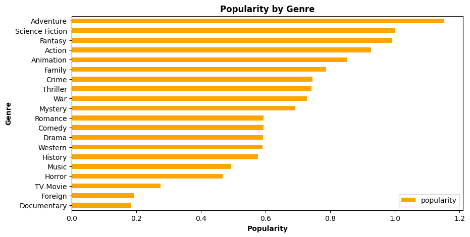

```python
# call myplot function:
myplot(movies_pop_genres,"barh", "genres", "popularity", "Popularity", "Genre", "Popularity by Genre", "orange")
```

```python
#movies_pop_genres.plot(x="genres", y="popularity", kind="barh", figsize=(10,5), color="orange");

# Add x label and format it:
#plt.xlabel("Popularity", size=10, fontweight="bold")
# Add y label and format it:
#plt.ylabel("Genre", size=10, fontweight="bold")
# Add title and format it:
#plt.title("Popularity by genre", size=12, fontweight = "bold");
```

As we can see in the plot above, the most popular genre of all times is adventure, followed by Science Fiction and Fantasy. The least popular genres are: TV Movie, Foreign and at least Documentary.

#### 1.2) Popularity of the movies over the years:

```python
movies_pop_years=movies.groupby("release_year").mean(numeric_only=True)["popularity"].reset_index().sort_values(by = "release_year", ascending = True)
```

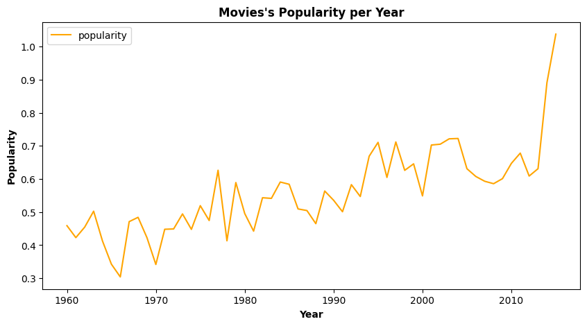

```python
# call myplot function:
myplot(movies_pop_years,"line", "release_year", "popularity", "Year", "Popularity", "Movies's Popularity per Year", "orange")
```

```python
#movies_pop_years.plot(x="release_year", y="popularity", kind="line", color="orange", figsize=(10,5));

# Add x label and format it:
#plt.xlabel("Year", size=10, fontweight="bold")
# Add y label and format it:
#plt.ylabel("Popularity", size=10, fontweight="bold")
# Add title label and format it:
#plt.title("Movies's Popularity per Year", size=12, fontweight = "bold");
```

We can see that although popularity has had ups and downs over the years, in the most recent decade there is a notable increase in this variable. Maybe it's because of the spread of digitalization and social networks that allow movies to become more and more popular among people.

#### 1.3) Correlations:

I will study the relatioship between popularity and other variables using scatter plots.

```python
# Create a function to create a scatterplot to avoid repetitive code:

def scatterplot(df, xvar, yvar, units_x, units_y, color):

    # Calculate correlation:
    corr = df[[xvar, yvar]].corr().iloc[0,1]

    # Plot:
    df.plot(kind="scatter", x=xvar, y=yvar, s=6, label=f'Correlation:{corr:0.3f}', figsize=[14,6], color=color)

    # Tidy up labels:
    xvar=xvar.replace("_"," ").title() #replace _ with a space and capitalize the first character
    yvar=yvar.replace("_"," ").title() #replace _ with a space and capitalize the firrst character

    # Add title and format it:
    plt.title(f'Relashionship between {yvar} and {xvar}'.title(), fontsize = 12, weight = "bold")

    # Add x label and format it:
    # I use an if statetment so that if I don't want to show units in the x label the "()" doesn't appear
    if units_x == "":
        plt.xlabel(f'{xvar} {units_x}', fontsize = 10, weight = "bold")
    else:
        plt.xlabel(f'{xvar} ({units_x})', fontsize = 10, weight = "bold")
    # The same for y labels:
    if units_y == "":
        plt.ylabel(f'{yvar} {units_y}', fontsize = 10, weight = "bold")
    else:
        plt.ylabel(f'{yvar} ({units_y})', fontsize = 10, weight = "bold")

    # Add legend:
    plt.legend()
```

#### 1.3.1) Popularity and runtime:

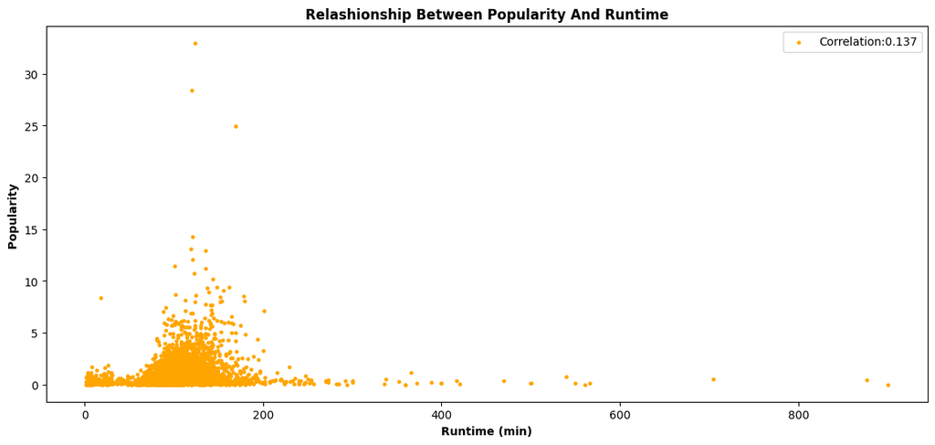

```python
# call scatterplot function:

scatterplot(movies, "runtime", "popularity", "min", "", "orange")
```

#### 1.3.2) Popularity and vote average:

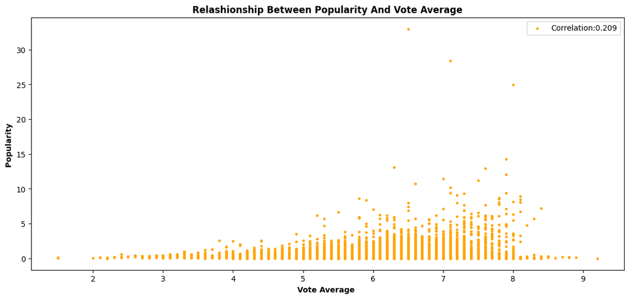

```python
# call scatterplot function:

scatterplot(movies, "vote_average", "popularity", "", "", "orange")
```

#### 1.3.3) Popularity and budget:

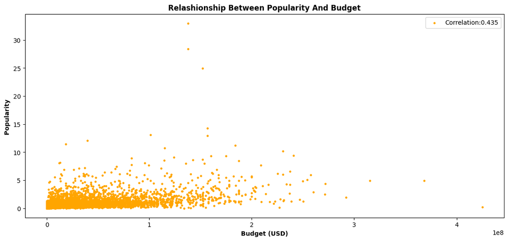

```python
# call scatterplot function:

scatterplot(movies, "budget", "popularity", "USD", "", "orange")
```

#### 1.3.4) Popularity and revenue:

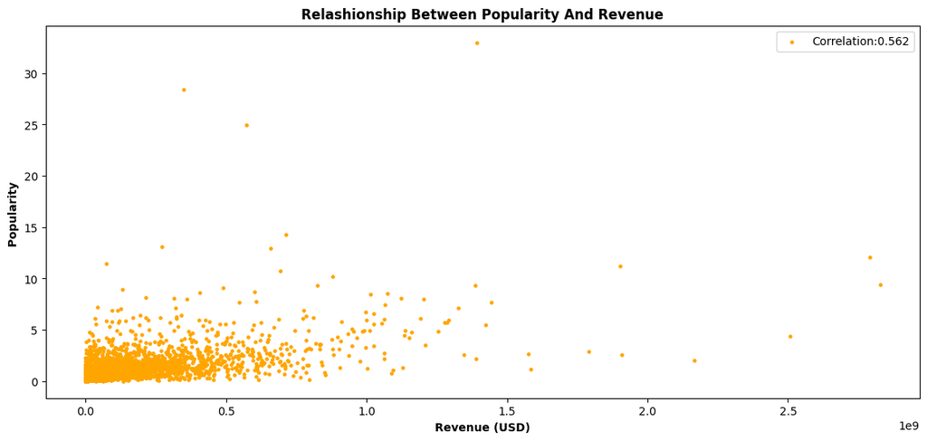

```python
# call scatterplot function:

scatterplot(movies, "revenue", "popularity", "USD", "", "orange")
```

#### 1.3.5) Popularity and profit:

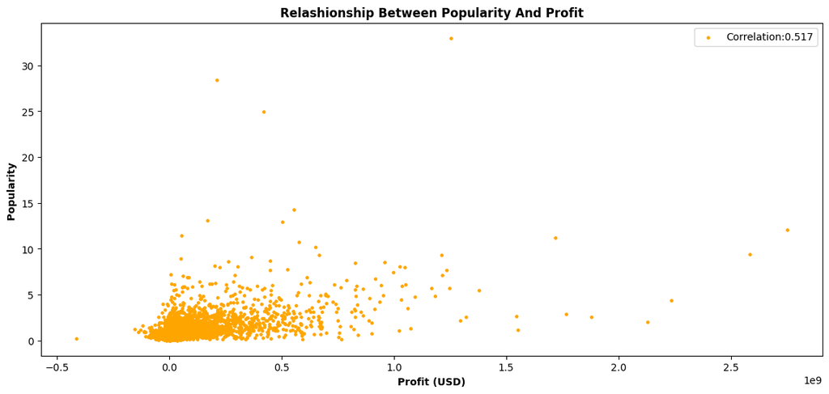

```python
# call scatterplot function:

scatterplot(movies, "profit", "popularity", "USD", "", "orange")
```

Observing all scatter plot we can see that there is no correlation between popularity and runtime and between popularity and vote average.

Variables like budget, revenue and profit, show a moderate positive correlation with popularity, however, they're not strong enough to take serious conclusions.

### 2) Movies released per year:

#### 2.1) Nº of movies produced per year?

To answer this question I'll use the "movies" dataframe, group by release year, count all movies per year (by the "id") and then show it in a line plot.

```python
movies_by_year=movies.groupby("release_year")["id"].count().reset_index()
movies_by_year = movies_by_year.sort_values(by = "release_year", ascending = True)
```

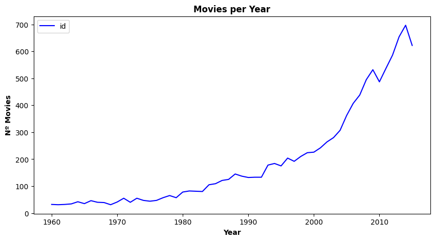

```python
# call myplot function:
myplot(movies_by_year,"line", "release_year", "id", "Year", "Nº Movies", "Movies per Year", "blue")
```

```python
#movies_by_year.plot(x="release_year", y="id", kind="line", color="blue", figsize=(10,5));

# Add x label and format it:
#plt.xlabel("Year", size=10, fontweight="bold")
# Add y label and format it:
#plt.ylabel("Nº Movies", size=10, fontweight="bold")
# Add title label and format it:
#plt.title("Movies per Year", size=12, fontweight = "bold");
```

```python
np.median(movies["release_year"])
```

```
2006.0
```

The number of movies released per year increased over time but more significantly from 2005/2006.

#### 2.2) Movies rating per year?

```python
movies_rating_year=movies.groupby("release_year").mean(numeric_only=True)["vote_average"].reset_index().sort_values(by = "release_year", ascending = True)
```

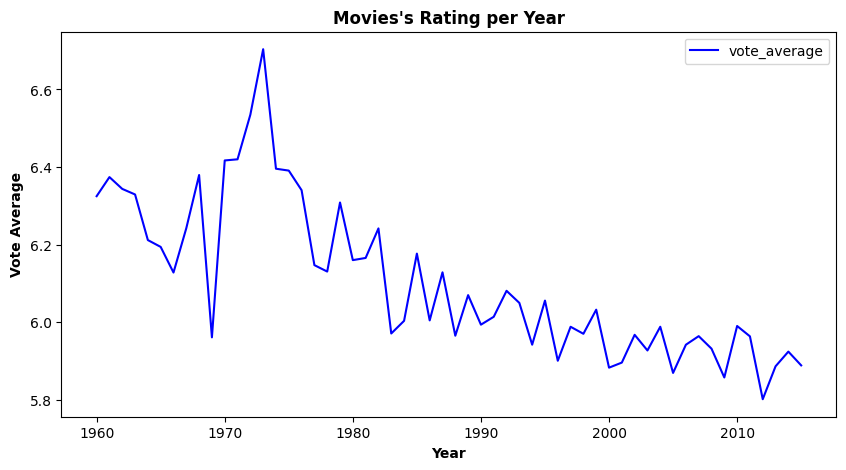

```python
# call myplot function:
myplot(movies_rating_year,"line", "release_year", "vote_average", "Year", "Vote Average", "Movies's Rating per Year", "blue")
```

```python
#movies_rating_year.plot(x="release_year", y="vote_average", kind="line", color="blue", figsize=(10,5));

# Add x label and format it:
#plt.xlabel("Year", size=10, fontweight="bold")
# Add y label and format it:
#plt.ylabel("Vote Average", size=10, fontweight="bold")
# Add title and format it:
#plt.title("Movies's Rating per Year", size=12, fontweight = "bold");
```

Although there are many ups and downs in the average vote of the movies, we can see a tendency of decrease in the most recent years. It can indicate that even if more movies were produced after 2000's, the movies quality hasn't increased the same way. Another point of view may be that the new generations of viewers is more demanding and critical.

#### 2.3) Average profit per year?

```python
movies_profit_year=movies.groupby("release_year").mean(numeric_only=True)["profit"].reset_index().sort_values(by = "release_year", ascending = True)
```

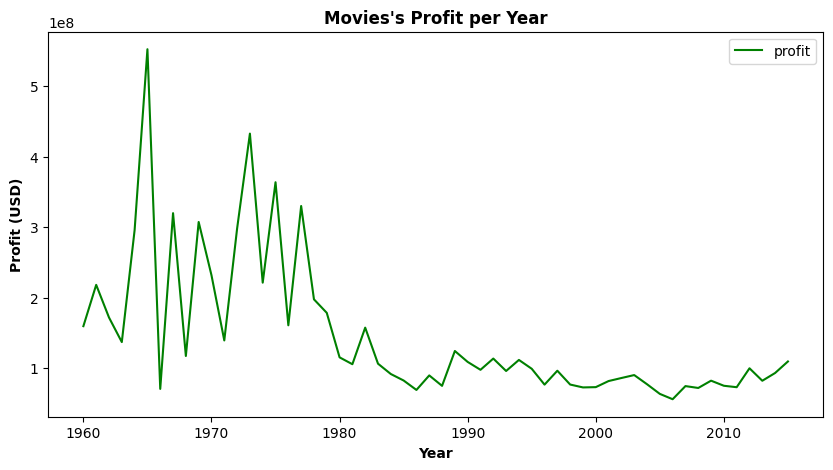

```python
# call myplot function:
myplot(movies_profit_year,"line", "release_year", "profit", "Year", "Profit (USD)", "Movies's Profit per Year", "green")
```

```python
#movies_profit_year.plot(x="release_year", y="profit", kind="line", color="green", figsize=(10,5));

# Add x label and format it:
#plt.xlabel("Year", size=10, fontweight="bold")
# Add y label and format it:
#plt.ylabel("Profit (USD)", size=10, fontweight="bold")
# Add title and format it:
#plt.title("Movies's Profit per Year", size=12, fontweight = "bold");
```

We can see that the average profit of movies were higher in the most old times. It may be explained by the golden era of cinema, or because maybe the most profitable movies of all times where released in the 70's and 80's (and by those years less movies were produced compared to the next decades) or because budgets have increased in the most recent times... I'll look for some conclusions about that in the next plots.

#### 2.4) Most profitable movies?

```python
movies.sort_values(by = "profit", ascending = False, inplace=True)
```

```python
movies[["original_title","release_year","profit"]].head(5)
```

|  | original_title | release_year | profit |
| --- | --- | --- | --- |
| 1329 | Star Wars | 1977 | 2.750137e+09 |
| 1386 | Avatar | 2009 | 2.586237e+09 |
| 5231 | Titanic | 1997 | 2.234714e+09 |
| 10594 | The Exorcist | 1973 | 2.128036e+09 |
| 9806 | Jaws | 1975 | 1.878643e+09 |

We can see that in the top 5 most profitable movies, 3 are from the 70's.

### 3) What is the impact of genres in the movies statistics?

#### 3.1) Number of movies by genre?

```python
movies_genres['genres'].value_counts().plot(kind='pie', figsize=(8,8));

# Add y label and format it:
plt.ylabel("Genre", size=10, fontweight="bold")
# Add title and format it:
plt.title("Number of Movies by Genre", size=12, fontweight = "bold");
```

[output not shown]

[output not shown]

#### 3.2) What is the average profit by genre?

```python
movies_prof_genres=movies_genres_merged.groupby("genres").mean(numeric_only=True)[["profit"]].reset_index()
movies_prof_genres.sort_values(by = "profit", ascending = True, inplace = True)
```

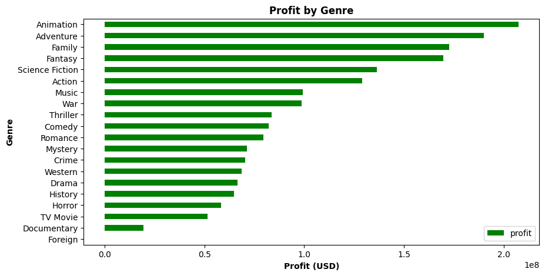

```python
# call myplot function:
myplot(movies_prof_genres,"barh", "genres", "profit", "Profit (USD)", "Genre", "Profit by Genre", "green")
```

```python
#movies_prof_genres.plot(x="genres", y="profit", kind="barh", color="green", figsize=(10,5));

# Add x label and format it:
#plt.xlabel("Profit (USD)", size=10, fontweight="bold")
# Add y label and format it:
#plt.ylabel("Genre", size=10, fontweight="bold")
# Add title and format it:
#plt.title("Profit by Genre", size=12, fontweight = "bold");
```

#### 3.3) What is the genre with better ratings:

```python
movies_genres_rating=movies_genres_merged.groupby("genres").mean(numeric_only=True)[["vote_average"]].reset_index()
movies_genres_rating.sort_values(by = "vote_average", ascending = True, inplace = True)
```

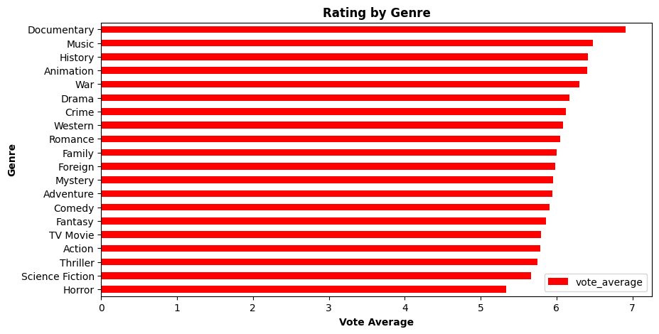

```python
# call myplot function:
myplot(movies_genres_rating,"barh", "genres", "vote_average", "Vote Average", "Genre", "Rating by Genre", "red")
```

```python
#movies_genres_rating.plot(x="genres", y="vote_average", kind="barh", title="Rating by Genre", color="red", figsize=(10,5), xlabel="Vote Average", ylabel="Genres" );

# Add x label and format it:
#plt.xlabel("Vote Average", size=10, fontweight="bold")
# Add y label and format it:
#plt.ylabel("Genre", size=10, fontweight="bold")
# Add title and format it:
#plt.title("Rating by Genre", size=12, fontweight="bold");
```

The genre with better ratings (mean vote average by genre) is the Documentary and worst is Horror. It shows that documentaries are associated with better quality and are apreciated by the audience, although it's the less popular genre (as seen in question 1.1).

### 4) Top 5 in Movies:

#### 4.1) Top 5 Directors:

```python
movies_top5_directors=movies_director_merged.groupby("director").count()[["id"]].reset_index()
movies_top5_directors.sort_values(by = "id", ascending = False, inplace = True)
top5_directors=movies_top5_directors.head(5)
print(top5_directors)
```

```
              director  id
5263       Woody Allen  46
935     Clint Eastwood  34
3346   Martin Scorsese  31
4840  Steven Spielberg  30
4246      Ridley Scott  23
```

The top 5 directors with more movies released are: Woody Allen, Clint Eastwood, Martin Scorsese, Steven Spielberg and Ridley Scott.

#### 4.2) Top 5 Production Companies:

```python
movies_top5_pc = movies_pc_merged.groupby("production_companies")["id"].count().reset_index()
movies_top5_pc.sort_values(by="id", ascending=False, inplace=True)
top5_production_companies = movies_top5_pc.head(5)
print(top5_production_companies)
```

```
                        production_companies   id
7365                      Universal Pictures  522
7575                            Warner Bros.  509
5296                      Paramount Pictures  431
7250  Twentieth Century Fox Film Corporation  282
1601                       Columbia Pictures  272
```

The top 5 production companies with more movies release are: Universal Pictures, Warner Bros., Paramount Pictures, Twentieth Century Fox Film Corporation and Columbia Pictures.

#### 4.3) Top 5 cast:

```python
movies_top5_cast = movies_cast_merged.groupby("cast")["id"].count().reset_index()
movies_top5_cast.sort_values(by="id", ascending=False, inplace=True)
top5_cast = movies_top5_cast.head(5)
print(top5_cast)
```

```
                    cast  id
15292     Robert De Niro  72
16029  Samuel L. Jackson  71
2500        Bruce Willis  62
13580       Nicolas Cage  61
12544      Michael Caine  53
```

The top 5 actors with more movies release are: Robert de Niro, Samuel L.Jackson, Bruce Wilis, Nicolas Cage and Miachael Caine.

#### 4.4) Top 5 popular movies:

```python
movies.sort_values(by = "popularity", ascending = False, inplace =True)
```

```python
movies["original_title"].head(5)
```

```
0               Jurassic World
1           Mad Max: Fury Road
629               Interstellar
630    Guardians of the Galaxy
2                    Insurgent
Name: original_title, dtype: object
```

The top 5 more popular movies are: Jurassic World, Mad Max: Fury Road, Interstellar, Guardians of the Galaxy and Insurgent.

#### 4.5) Top 5 expensive movies:

```python
movies = movies.sort_values(by = "budget", ascending = False)
```

```python
movies["original_title"].head(5)
```

```
2244                              The Warrior's Way
3375    Pirates of the Caribbean: On Stranger Tides
7387       Pirates of the Caribbean: At World's End
6570                               Superman Returns
5231                                        Titanic
Name: original_title, dtype: object
```

The top5 largest budget movies are: The Warrior's Way, Pirates of the Caribbean: On Stranger Tides, Pirates of the Caribbean: At World's End, Superman Returns and Titanic.

#### 4.6) Top 5 revenue:

```python
movies = movies.sort_values(by = "revenue", ascending = False)
```

```python
movies["original_title"].head(5)
```

```
1386           Avatar
1329        Star Wars
5231          Titanic
10594    The Exorcist
9806             Jaws
Name: original_title, dtype: object
```

The top 5 best seller movies are: Avatar, Star Wars, Titanic, The Exorcist and Jaws. Titanic is among the top 5 expensive but also best seller movies.

### 5) Budget vs Revenue

#### 5.1) Is there any linear correlation between budget and revenue?

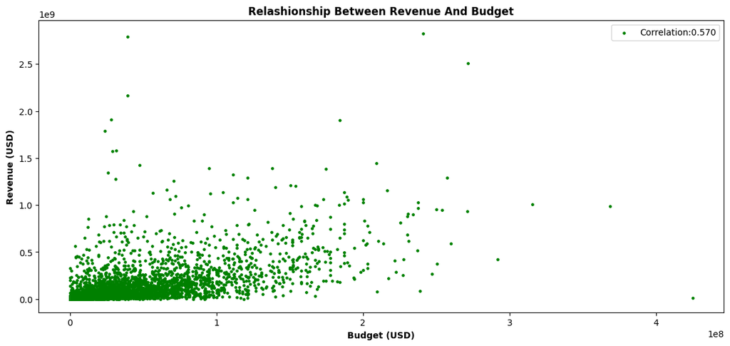

```python
# call scatterplot function:

scatterplot(movies, "budget", "revenue", "USD", "USD", "green")
```

As we can see by the plot above, there is a moderate positive correlation between these 2 variables.

## Conclusions

The conclusions have been indicated along the analysis of the data. The main points are:

Popularity has had ups and downs over the years but most recentyly there is an increase in populariry levels, maybe because of digitalization and social networks that are very useful to promote movies. The most popular genre of all times is Adventure and I didn't find any strong correlation between popularity and other variables, although there is a moderate positive correlation between popularity and revenue and profit. The most popular movies are: Jurassic World, Mad Max: Fury Road, Interstellar, Guardians of the Galaxy and Insurgent.

The number of movies released per increased over time but more significantly from 2005/2006. By contrary, in terms of vote average and profit this tendency is not observed, and we can see a decrease over time.

In terms of more release movies, I found the following top 5:

- Directos: Woody Allen, Clint Eastwood, Martin Scorsese, Steven Spielberg and Ridley Scott.
- Production companies: Universal Pictures, Warner Bros., Paramount Pictures, Twentieth Century Fox Film Corporation and Columbia Pictures.
- Actors: Robert de Niro, Samuel L.Jackson, Bruce Wilis, Nicolas Cage and Miachael Caine.

In terms of financial results, the top 5 are:

- Biggest Budget: The Warrior's Way, Pirates of the Caribbean: On Stranger Tides, Pirates of the Caribbean: At World's End, Superman Returns and Titanic.
- Biggest Renevue: Avatar, Star Wars, Titanic, The Exorcist and Jaws.

I found a moderate positive correlation between budget and revenue.

### Limitations of the dataset:

The original dataset has more than 10865 different rows. However there are issues with the data because almost 7000 rows have zero in the budget or revenue column. These data represents more than 60% of the original data and can not be used in the statistical analysis like correlations.

There is also lack of information about some data, for example popularity (how it was measured and units?).

For further analysis it would be interesting to add more complexity to the data, and have more information about revenues and budgets missing.

## Submitting your Project

> **Tip**: Before you submit your project, you need to create a .html or .pdf version of this notebook in the workspace here. To do that, run the code cell below. If it worked correctly, you should see output that starts with `NbConvertApp] Converting notebook`, and you should see the generated .html file in the workspace directory (click on the orange Jupyter icon in the upper left).

> **Tip**: Alternatively, you can download this report as .html via the **File** > **Download as** submenu, and then manually upload it into the workspace directory by clicking on the orange Jupyter icon in the upper left, then using the Upload button.

> **Tip**: Once you've done this, you can submit your project by clicking on the "Submit Project" button in the lower right here. This will create and submit a zip file with this .ipynb doc and the .html or .pdf version you created. Congratulations!

```python
# Running this cell will execute a bash command to convert this notebook to an .html file
!python -m nbconvert --to html Investigate_a_Dataset.ipynb
```

```
[NbConvertApp] Converting notebook Investigate_a_Dataset.ipynb to html
[NbConvertApp] Writing 1574875 bytes to Investigate_a_Dataset.html
```